# Wilfong Project Three

Isaac Wilfong

2025-05-23

# Question 1

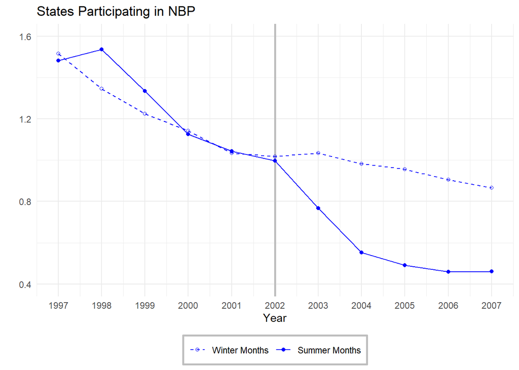

# Question 2

The identification assumption underlying the model of just the states that took part in the NBP program, is the parallel trends assumption. We are assuming that emissions year to year would follow a similar trend before the program started to after the program started. In our graph of states participating in NBP, the winter months and the summer months look to be following the same trend up until the policy began. Before the program started summer months emissions and winter months emissions were closely intertwined following a downward trend. Then after the program begins, the two lines follow two separate trends. Winter months remain at a slight downward trend while summer months drop much steeper than winter months. This causes a wide gap between the two lines.

|  | *Dependent variable:* |
| --- | --- |
|  | nox_emit |
| year | -0.085*** |
|  | (0.027) |
| summer | 28.974 |
|  | (75.260) |
| year:summer | -0.014 |
|  | (0.038) |
| Constant | 170.357*** |
|  | (53.217) |
| Observations | 14,220 |
| R<sup>2</sup> | 0.002 |
| Adjusted R<sup>2</sup> | 0.001 |
| Residual Std. Error | 3.833 (df = 14216) |
| F Statistic | 8.094*** (df = 3; 14216) |
| *Note:* | p<0.1; p<0.05; p<0.01 |

The year and summer indicator variable interaction term is not statistically significant. This means that there were no differences in pre-policy trends between the summer months and the winter months.

# Question 3

In the table below, summer months saw an additional decrease in emissions by 0.373 units than the winter months after the policy went in to effect.

|  | *Dependent variable:* |
| --- | --- |
|  | nox_emit |
| summer | 0.034 |
|  | (0.207) |
| post | -0.223*** |
|  | (0.031) |
| summer:post | -0.373*** |
|  | (0.096) |
| Constant | 1.024*** |
|  | (0.148) |
| Observations | 26,070 |
| R<sup>2</sup> | 0.005 |
| Adjusted R<sup>2</sup> | 0.005 |
| Residual Std. Error | 3.233 (df = 26066) |
| F Statistic | 45.650*** (df = 3; 26066) |
| *Note:* | p<0.1; p<0.05; p<0.01 |

# Question 4

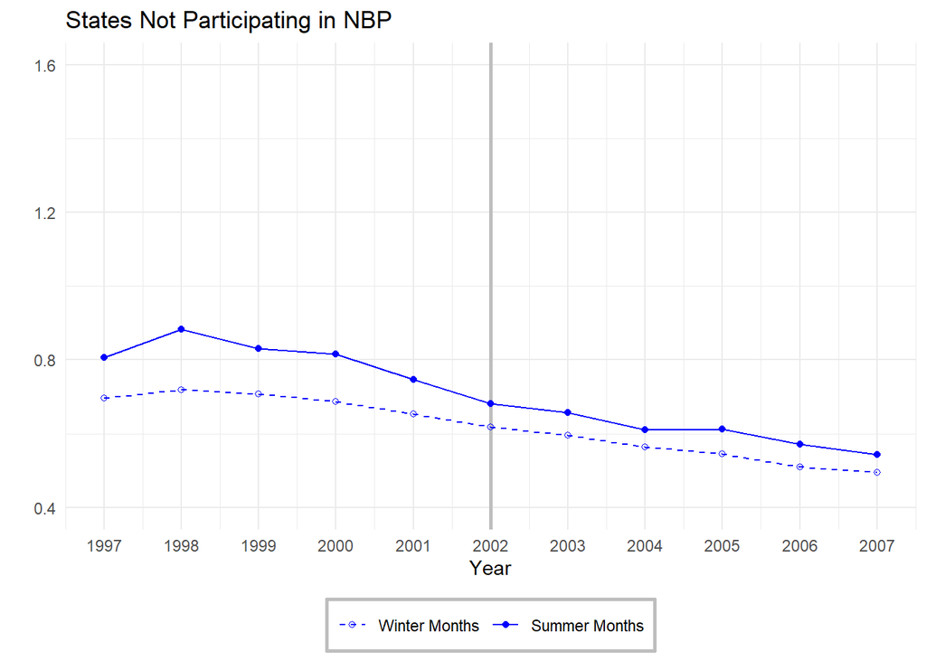

The plot above or panel B in the paper serves as a placebo test. Since these states are not subject to the same policy as the states that opted into the NBP cap and trade program, we would expect that these states saw no difference before and after the policy. This graph adds more validity to our hypothesis that the NBP can help lower emissions. If there was a similar divide between summer and winter months like that in the graph in question 1 also known as the graph in panel A, then we would suspect that something other than the NBP program is responsible for that change. However, since there is no visible change in trends after the cutoff between winter and summer months than this graph provides further evidence to the treatment being the cause behind the shift.

# Question 5

|  | *Dependent variable:* |
| --- | --- |
|  | nox_emit |
| summer | 0.084 |
|  | (0.138) |
| post | -0.102** |
|  | (0.042) |
| summer:post | -0.042 |
|  | (0.076) |
| Constant | 0.502*** |
|  | (0.084) |
| Observations | 29,788 |
| R<sup>2</sup> | 0.001 |
| Adjusted R<sup>2</sup> | 0.001 |
| Residual Std. Error | 2.074 (df = 29784) |
| F Statistic | 11.376*** (df = 3; 29784) |
| *Note:* | p<0.1; p<0.05; p<0.01 |

The results on the summer*post interaction term is not significant meaning there is no clear relationship between the date the policy was passed and a differential change in emissions during summer months compared to winter months in these unregulated states.

# Question 6

Below I am filtering out all the data before the policy went into affect and filtering out all winter data to just have summer data left over. I am then running a pre-trends regression with an interaction term between the year and whether the state was an NBP state. If this variable is significant then this will show us if there was a divergance of emissions before the policy began between states participating in the program and states not participating in the program.

|  | *Dependent variable:* |
| --- | --- |
|  | nox_emit |
| year | -0.022 |
|  | (0.020) |
| nbp | 154.532*** |
|  | (59.879) |
| year:nbp | -0.077** |
|  | (0.030) |
| Constant | 44.799 |
|  | (40.908) |
| Observations | 15,234 |
| R<sup>2</sup> | 0.007 |
| Adjusted R<sup>2</sup> | 0.007 |
| Residual Std. Error | 3.149 (df = 15230) |
| F Statistic | 35.546*** (df = 3; 15230) |
| *Note:* | p<0.1; p<0.05; p<0.01 |

In the table above the year and NBP interaction term is significant to the 5% level. This shows us that there was a divergence before the policy between the states that participated in the program versus states that did not. The results of this regression tell us that running a difference in differences alone would result in bias estimations. That is what brings us to the triple differences framework.

A triple differences framework would help us add a third dimension to the model to help account for the differences in states that are willing to participate in the program versus not willing to participate. The test below will be a regression model of year * NBP * summer to test whether triple differences will be able to work in this context.

|  | *Dependent variable:* |
| --- | --- |
|  | nox_emit |
| year | -0.013 |
|  | (0.020) |
| nbp | 144.310** |
|  | (58.751) |
| summer | 18.752 |
|  | (56.762) |
| year:nbp | -0.072** |
|  | (0.029) |
| year:summer | -0.009 |
|  | (0.028) |
| nbp:summer | 10.222 |
|  | (83.086) |
| year:nbp:summer | -0.005 |
|  | (0.042) |
| Constant | 26.047 |
|  | (40.137) |
| Observations | 30,468 |
| R<sup>2</sup> | 0.008 |
| Adjusted R<sup>2</sup> | 0.008 |
| Residual Std. Error | 3.090 (df = 30460) |
| F Statistic | 33.963*** (df = 7; 30460) |
| *Note:* | p<0.1; p<0.05; p<0.01 |

The coefficient on the interaction term between the year, nbp, and summer variable is insignificant. This provides evidence that a triple difference framework would work in this context.

# Question 7

The below table shows a triple difference model run with all of the data and an interaction term between the nbp, summer, and post variables.

|  | *Dependent variable:* |
| --- | --- |
|  | nox_emit |
| nbp | 0.522*** |
|  | (0.170) |
| summer | 0.084 |
|  | (0.138) |
| post | -0.102** |
|  | (0.042) |
| nbp:summer | -0.050 |
|  | (0.248) |
| nbp:post | -0.121** |
|  | (0.052) |
| summer:post | -0.042 |
|  | (0.076) |
| nbp:summer:post | -0.331*** |
|  | (0.122) |
| Constant | 0.502*** |
|  | (0.084) |
| Observations | 55,858 |
| R<sup>2</sup> | 0.009 |
| Adjusted R<sup>2</sup> | 0.008 |
| Residual Std. Error | 2.678 (df = 55850) |
| F Statistic | 68.541*** (df = 7; 55850) |
| *Note:* | p<0.1; p<0.05; p<0.01 |

The coefficient for the triple difference estimate is -0.331. The triple difference estimate represents the differential impact over three dimensions. In this case these three dimensions are whether or not the observation was apart of an NBP state or not, time (whether this was pre or post policy), and subgroup (winter of summer months). The estimate means that the policy reduced NOx emissions by -0.331 short tons more in the summer than in the winter beyond the seasonal variation.

This estimate is similar to the estimate in question 3. In question 3, the model that was ran was a difference in differences model of just the states that were in the NBP program. This model was isolating the treatment effect of just the policy on the emissions reduction between summer and winter. What the model in question 3 is missing is the seasonal effects which are overestimating the effect of the policy since there was a difference in summer and winter months pre-policy. Question 7’s model is accounting for that. This results in slightly different estimates however similar at the surface in the DiD model and the DDD model.

In question 5, we had the same model except that the data only included observations from states not in the NBP. The coefficient in question 5 is only showing the differences between winter and summer pre and post policy. Although this estimate is not significant, it is non-zero and could lead us to expect that the DiD model in question 3 was overestimating the effect of the policy which the triple difference model further showed.

# Question 8

# Question 9

```
## OLS estimation, Dep. Var.: nox_emit
## Observations: 55,858
## Fixed-effects: fips_county: 2,539,  time_id: 22
## Standard-errors: Clustered (fips_county)
##                  Estimate Std. Error  t value   Pr(>|t|)
## nbp:summer      -0.050333   0.015213 -3.30851 9.5104e-04 ***
## nbp:post        -0.121287   0.036209 -3.34966 8.2095e-04 ***
## nbp:summer:post -0.331010   0.050566 -6.54612 7.1205e-11 ***
## ... 4 variables were removed because of collinearity (nbp, summer and 2 others [full set in $collin.var])
## ---
## Signif. codes:  0 '***' 0.001 '**' 0.01 '*' 0.05 '.' 0.1 ' ' 1
## RMSE: 1.00975     Adj. R2: 0.852285
##                 Within R2: 0.009014
```

The two-way fixed effects model removes county level and time specific variation. This leaves only county variation over time. The triple difference model estimate accounts for seasonal and policy differences thus the coefficient remains unchanged.

The coefficient would change if the parallel trends assumption was violated or if there was an omitted variable that was differentially affecting summer emission trends.

# Question 10

The paper is clustering standard errors by the state by season level. This is accounting for potential correlation in the error terms within each state and season combination while clustering at the state level just looking at correlations within the state level ignoring seasonal differences within state. Clustering by just the state level is more conservative as this would increase standard error bands by aggregating over a larger group.

**Triple-Difference Estimates with Different Clustering**

|  | *Dependent variable:* |  |
| --- | --- | --- |
|  | NOx Emissions (Short Tons) |  |
|  | State-Season Clustered SE | State Clustered SE |
|  | (1) | (2) |
| nbp | 0.522*** | 0.522*** |
|  | (0.170) | (0.043) |
| summer | 0.084** | 0.084** |
|  | (0.035) | (0.042) |
| post | -0.102** | -0.102** |
|  | (0.042) | (0.044) |
| nbp:summer | -0.050 | -0.050 |
|  | (0.039) | (0.062) |
| nbp:post | -0.121** | -0.121* |
|  | (0.052) | (0.065) |
| summer:post | -0.042* | -0.042 |
|  | (0.022) | (0.062) |
| nbp:summer:post | -0.331*** | -0.331*** |
|  | (0.070) | (0.091) |
| Constant | 0.502*** | 0.502*** |
|  | (0.084) | (0.030) |
| Observations | 55,858 | 55,858 |
| R<sup>2</sup> | 0.009 | 0.009 |
| Adjusted R<sup>2</sup> | 0.008 | 0.008 |
| Residual Std. Error (df = 55850) | 2.678 | 2.678 |
| F Statistic (df = 7; 55850) | 68.541*** | 68.541*** |
| *Note:* | p<0.1; p<0.05; p<0.01 |  |

**Triple-Difference Estimates with Different Clustering**

| (Intercept) | nbp | summer | post | nbp:summer | nbp:post | summer:post | nbp:summer:post |
| --- | --- | --- | --- | --- | --- | --- | --- |
| 0.084 | 0.170 | 0.138 | 0.042 | 0.248 | 0.052 | 0.076 | 0.122 |

The above table shows the standard errors clustering by the state-season level and by just the state level. The standard errors increase by .021 when you remove the season level clustering. This keeps significance to the 1% and either way of clustering in this case doesn’t change the overall result or the validity of the result.

# Code

```r
# Extract all code chunks
all_code <- knit_code$get()

# Print code
cat(unlist(all_code), sep = "\n")
```

```
## # loading in data
## nbp <- read.csv("nbp.csv")
##
## # loading in libraries
## library(tidyverse)
## library(ggplot2)
## library(patchwork)
## library(stargazer)
## library(knitr)
## library(sandwich)
## library(lmtest)
## library(fixest)
## #head(nbp)
## #colnames(nbp)
## #length(nbp$nbp) - sum(nbp$nbp)
##
## states_in <- nbp %>%
##   filter(nbp == 1) %>%
##   group_by(year, summer) %>%
##   summarize(mean_nox = sum(nox_emit)/1000)
##
## states_out <- nbp %>%
##   filter(nbp == 0) %>%
##   group_by(year, summer) %>%
##   summarize(mean_nox = sum(nox_emit)/1000)
##
## #length(states_in$nbp) + length(states_out$nbp) == length(nbp$nbp)
## #length(nbp$nbp) == length(na.omit(nbp$nbp))
##
##
## plot1 <- ggplot(states_in, aes(x = year, y = mean_nox, group = summer)) +
##   geom_vline(xintercept = 2002, color = "grey", size = 1) +
##   geom_line(aes(color = factor(summer), linetype = factor(summer)), size = .5) +
##   geom_point(aes(color = factor(summer), shape = factor(summer)), size = 1.5) +
##   scale_x_continuous(breaks = seq(min(states_in$year), max(states_in$year), by = 1)) +
##   scale_y_continuous(limits = c(.4, 1.6)) +
##   scale_color_manual(values = c("0" = "blue", "1" = "blue"), labels = c("Winter Months", "Summer Months")) +
##   scale_linetype_manual(values = c("0" = "dashed", "1" = "solid"), labels = c("Winter Months", "Summer Months")) +
##   scale_shape_manual(values = c("0" = 1, "1" = 16), labels = c("Winter Months", "Summer Months")) +
##   theme_minimal() +
```

[output cut: 176 more lines]

```
## robust_sediffstate <- sqrt(diag(cluster_sediffstate))
##
## stargazer(triple_diff, triple_diff,
##           se = list(robust_sediffstate), list(robust_sediff),
##           title = "Triple-Difference Estimates with Different Clustering",
##           dep.var.labels = "NOx Emissions (Short Tons)",
##           column.labels = c("State-Season Clustered SE", "State Clustered SE"),
##           type = "html", header=FALSE)
##
##
## # Extract all code chunks
## all_code <- knit_code$get()
##
## # Print code
## cat(unlist(all_code), sep = "\n")
```